# Project 2 Report

Group 1

Due 5 pm PST March 5th 2021

# Introduction

The effects of the COVID-19 pandemic on mental health have become an increasingly recognized issue in public discourse, yet mental health science perspectives remain relatively overlooked in the construction of research priorities and policy agendas related to recovery from the COVID-19 pandemic. Researchers recognize that the psychological and social effects of the COVID-19 pandemic on mental health are pervasive (Holmes & O’Connor et al., 2020, p. 547) and that, without government support, individuals are at risk of bearing a “psychological scar” (Clemente-Suárez et al, 2020, p. 4) long after the pandemic ends. Therefore, coordination between governments and global research platforms to prioritize understanding mental health outcomes during the COVID-19 pandemic is necessary to mitigate mental health consequences for vulnerable groups under current and future pandemic conditions (Holmes & O’Connor et al., 2020, p. 547).

The objective of this report is to inform readers about the impacts of COVID-19 on mental health in the United States. Although mental health is a global issue, the decentralized and inconsistent response to COVID-19 in the United States motivates us to explore populations in the United States as a case study for populations in countries implementing similar dynamic responses to the pandemic. The cyclic nature of lockdowns and control measures in the United States means Americans will continue to experience stressors associated with the COVID-19 pandemic. So, we hope that our findings will help advance knowledge about Americans’ vulnerability to negative mental health outcomes so that susceptible groups can be prioritized in government response and assistance programs related to COVID-19 or future pandemics.

To investigate the impact of COVID-19 on mental health in the United States, we explore data from the [WHO Coronavirus Dashboard](https://covid19.who.int/) and the [United States Census Bureau Household Pulse Survey (HPS)](https://www.cdc.gov/nchs/covid19/pulse/mental-health.htm). We also provide descriptive analysis of Google search queries related to anxiety and depression to supplement the HPS data and guide our hypotheses. We define our primary question of interest as whether an association exists between the number of confirmed COVID-19 cases and the frequency of indicators, or symptoms, of depressive or anxiety disorder. Furthermore, we define our secondary question of interest as, if an association exists between the number of confirmed COVID-19 cases and the frequency of indicators of depressive and anxiety disorder, whether a specific population in the United States experiences the greatest frequency of symptoms. To produce combined data sets for our analysis, we select the `Date_reported`, `Country`, `New_cases`, `Cumulative_cases`, `New_deaths`, and `Cumulative_deaths` variables from the WHO Coronavirus Dashboard and the `Indicator`, `Group`, `Time Period`, `Time Period Label`, `Time Period Start Date`, `Time Period End Date`, `Value`, `Low CI`, `High CI`, and `Quartile Range` variables from the HPS.

Prior analyses of HPS data suggest a disproportionate negative impact of COVID-19 stressors on emotional distress among older persons of color. (Bui et al, 2020, p. 262) and a significant mental health burden stemming from job insecurity among young adults amidst the COVID-19 pandemic [(Ganson et al., 2021, p. 55)](https://doi.org/10.1016/j.jadohealth.2020.10.008). Consequently, we hypothesize that the frequency of indicators of depressive or anxiety disorder increase as the new case count associated with COVID-19 grows in the United States. We also expect that, when comparing populations defined by ethnicity, non-White groups will have the greatest frequency of symptoms. When comparing populations defined by age, we expect to find the highest frequency of symptoms related to depressive or anxiety disorder among young adults, but older adults may also be vulnerable to a greater risk of symptoms.

# Background

Recent findings on the impacts of COVID-19 on mental well-being motivate our analysis. On a global scale, researchers have analyzed data from Google Trends to test whether COVID-19 and the associated lockdowns implemented in Europe and America led to changes in well-being related topic search terms; the detection of a significant increase in searches for loneliness, worry, and sadness suggests that people’s mental health may have been severely affected by the pandemic and lockdown [(Brodeur et al., 2020, p. 1)](https://doi.org/10.1016/j.jpubeco.2020.104346). Since data from before the pandemic and lockdowns began is necessary to fully assess how the COVID-19 affects population well-being, Brodeur et al. only analyzed data from Google Trends between January 1st 2019 and April 10th 2020 in countries that had introduced a full lockdown by the end of this period [(Brodeur et al., 2020, p. 1)](https://doi.org/10.1016/j.jpubeco.2020.104346). Therefore, we can interpret Brodeur et al.’s finding of a significant increase in search terms related to poor mental well-being as being associated with the pandemic and lockdowns. Brodeur et al.’s findings suggest that we may expect a positive relationship between the number of COVID-19 cases and the frequency indicators of anxiety and depression in the United States when addressing our primary question of interest.

On a national scale, researchers have identified disparities in the degree of negative mental health consequences associated with COVID-19 across age groups and ethnicities. For example, research in the United States, United Kingdom, and Italy consistently shows that younger adults are more vulnerable to increased psychological distress than older adults [(Abbott, 2020, p. 194](https://doi.org/10.1038/d41586-021-00175-z); [Delmastro & Zamariola, 2020, p. 8)](https://doi.org/10.1038/s41598-020-79850-6), and that within the United States, job insecurity associated with the pandemic might exacerbate symptoms of poor mental health among young people [(Ganson et al., 2021, p. 55)](https://doi.org/10.1016/j.jadohealth.2020.10.008). In addition, greater frequencies of negative health outcomes among minority ethnicities may stem from being disproportionately affected by COVID-19 containment policies [(Abbott et al., 2021, p. 194)](https://doi.org/10.1038/d41586-021-00175-z) or from expectations regarding future inability to recover lost economic resources in the future [(Bui et al, 2020, p. 262)](https://doi.org/10.1093/geront/gnaa217). Since these findings come from analysis on data from either large, representative samples or the HPS, we expect to find similar disparities across age or ethnicities when exploring our secondary question of interest.

We compiled and filtered data from the WHO COVID-19 Dashboard and the HPS to produce the data set for our model. The WHO Coronavirus Dashboard reflects laboratory-confirmed cases and deaths based upon WHO case definitions [(World Health Organization [WHO], 2020)](https://covid19.who.int/). All WHO COVID-19 data represents the date of reporting as opposed to date of symptom onset and counts of new cases and deaths were calculated by subtracting previous cumulative total counts from the current count [(WHO, 2020)](https://covid19.who.int/). The HPS was developed to help understand the social and economic impacts of COVID-19 on American households and designed to meet the goal of accurate and timely weekly estimates [(Fields et al., 2020, p. 3)](https://www2.census.gov/programs-surveys/demo/technical-documentation/hhp/2020_HPS_Background.pdf). HPS investigators expected low response rates, so they applied a weighting procedure within each state consisting of four adjustments that were applied to the base weights [(Fields et al., 2020, p. 6)](https://www2.census.gov/programs-surveys/demo/technical-documentation/hhp/2020_HPS_Background.pdf). Although the HPS produced responses related to many social and economic measures across three different geographic levels (estimates for the 15 largest Metropolitan Statistical Areas, state-level estimates for each of the 50 states and the District of Columbia, and national-level estimates), our predictive analysis is based on national-level estimates of the percentage of respondents who report experiencing symptoms associated with diagnoses of generalized anxiety disorder or major depressive disorder.

# Descriptive Analysis

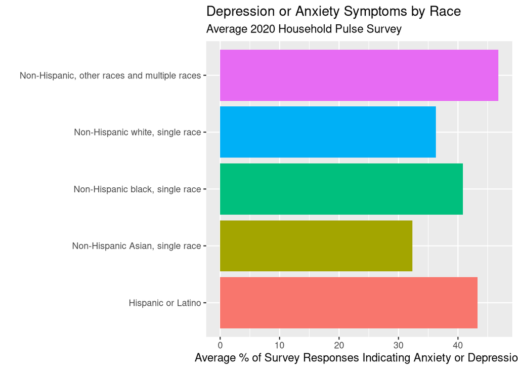

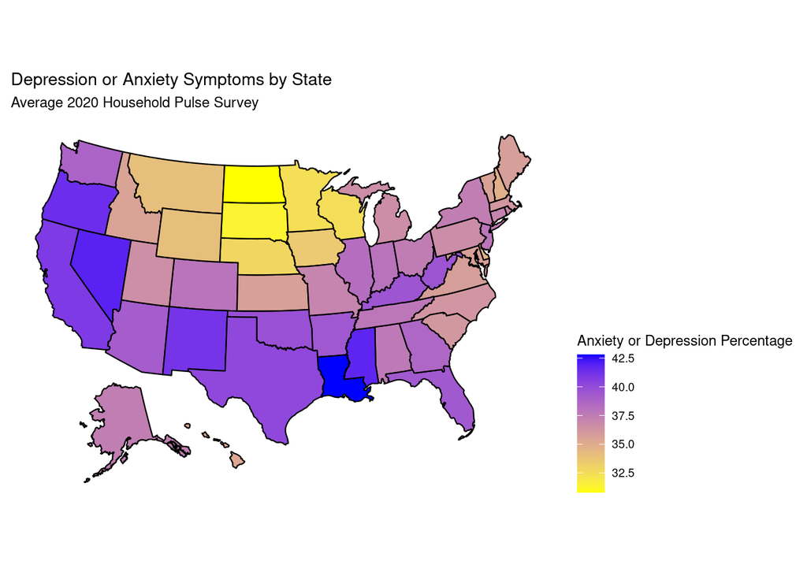

To present these several datasets on the same time line, the time frame was restricted to the 2020 calendar year. Since all the datasets except for the WHO COVID-19 cases and deaths are recorded in constant time periods that are greater than a day, they were considered to be constant during their respective sampling period. For example, the Google trends data on Anxiety is recorded every week. The value recorded every week is assigned to every day of that week. This allows for simple visual comparisons as shown below.

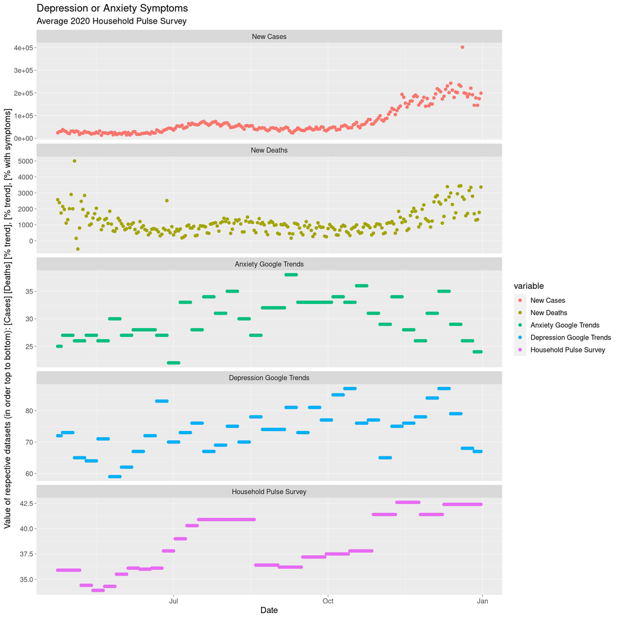

Strangely, the month of May has a day with a negative number of deaths and the maximum number of deaths in a day is exactly 5,000. The first issue is impossible and the second issue is highly unlikely. Further investigation outside this report is warranted by this strange behavior, but for now the first error is assumed to be a correction of an over-count and the second error is assumed to be an estimate of that day’s number of deaths due to COVID. Both of these can be considered a part of the noise that naturally exists in the data.

# Predictive/Inferential Analysis

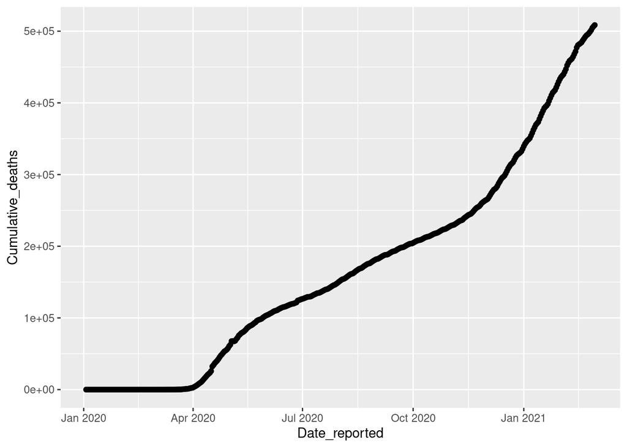

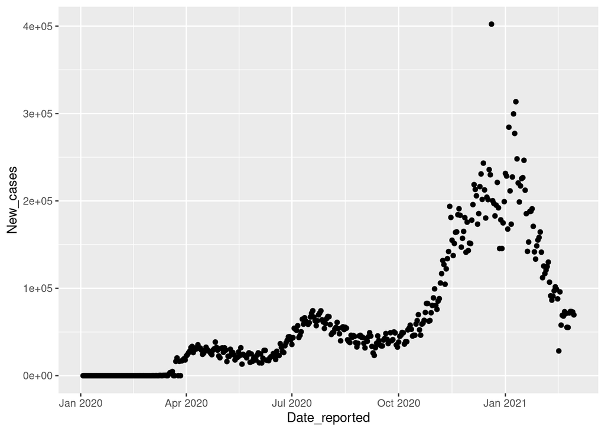

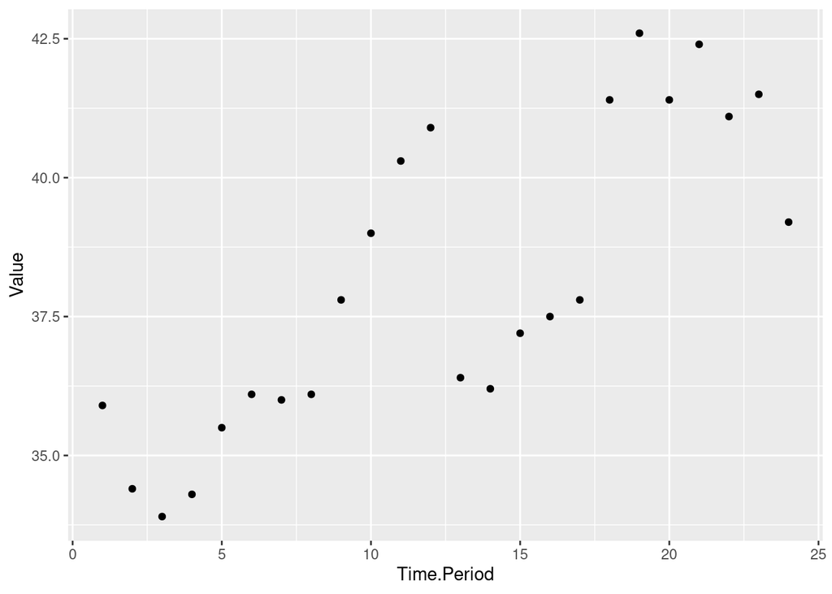

In order to create the linear model first the dates needed to be standardized. The CDC Depression and Anxiety data has 24 datapoints for distinct time periods. The WHO COVID-19 data has 427 datapoints for distinct days. The days in the WHO COVID-19 that math ot the time periods in the CDC Depression and Anxiety data were then compiled and averages were taken for new cases and new deaths. Doing this contrils for the time series variable in the data.

| dates | cases | deaths | anxiety_value |
| --- | --- | --- | --- |
| dates1 | 29082.92 | 1908.6154 | 35.9 |
| dates2 | 25144.83 | 1925.5000 | 34.4 |
| dates3 | 22893.50 | 1429.3333 | 33.9 |
| dates4 | 22022.33 | 1221.0000 | 34.3 |
| dates5 | 20790.33 | 1021.3333 | 35.5 |
| dates 6 | 22538.33 | 868.6667 | 36.1 |
| dates7 | 21416.00 | 785.6667 | 36.0 |
| dates8 | 28441.17 | 630.1667 | 36.1 |
| dates9 | 40394.00 | 1005.3333 | 37.8 |
| dates10 | 50640.83 | 511.6667 | 39.0 |

[output cut: 14 more lines]

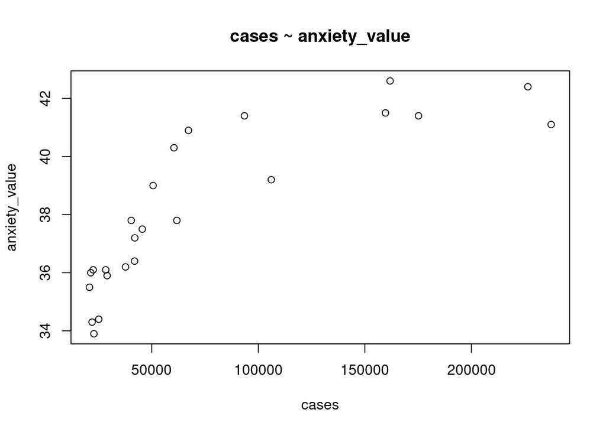

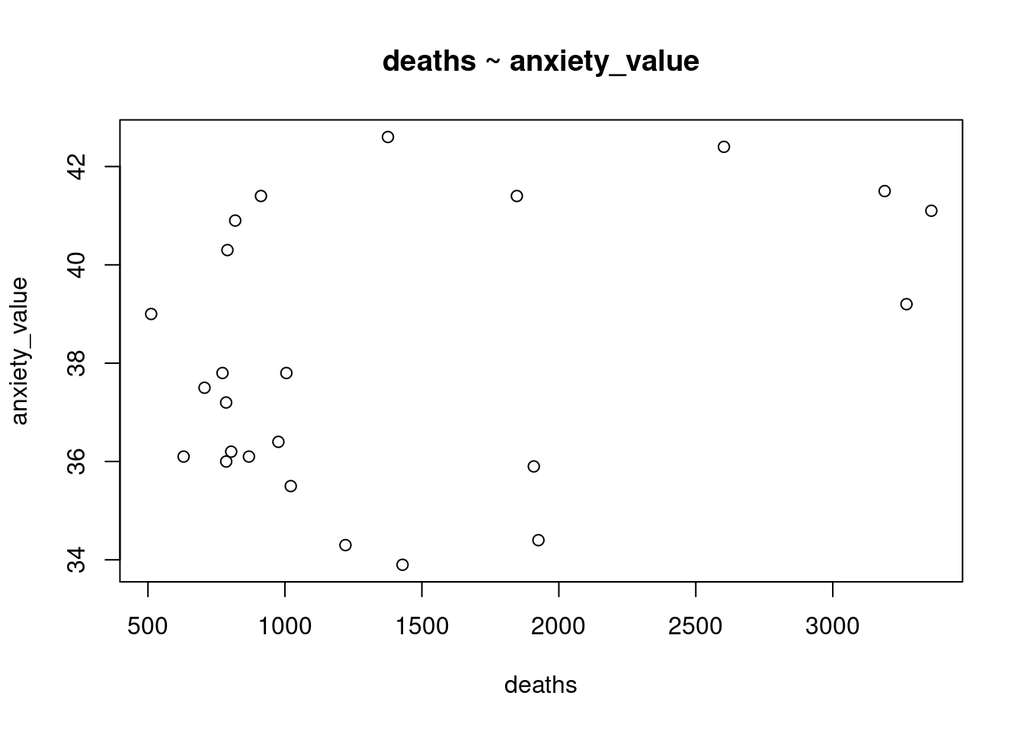

This model assumes that the relationship between $X$ and $Y$ is linear and for ant fixed value of $X$, $Y$ is normally distributed. This model also assumes homoscedasticity, that the variance of residuals is the same for any value of $X$, and independence, that each observation is independent of each other. In order to put the values for $X$ and $Y$ on a similiar scale the log of $Y$ was used in the model.

```
##
## Call:
## lm(formula = log(cases) ~ anxiety_value, data = compiled_data)
##
## Residuals:
##      Min       1Q   Median       3Q      Max
## -0.52978 -0.26460 -0.00436  0.22306  0.67797
##
## Coefficients:
##               Estimate Std. Error t value Pr(>|t|)
## (Intercept)    0.65076    0.90521   0.719     0.48
## anxiety_value  0.26883    0.02369  11.349 1.15e-10 ***
## ---
## Signif. codes:  0 '***' 0.001 '**' 0.01 '*' 0.05 '.' 0.1 ' ' 1
##
## Residual standard error: 0.3119 on 22 degrees of freedom
## Multiple R-squared:  0.8541, Adjusted R-squared:  0.8475
## F-statistic: 128.8 on 1 and 22 DF,  p-value: 1.151e-10
```

The reported summary for this model relating $Y$, number of new covid cases, to $X$ the value reported in the CDC Depression and Anxiety data, shows a positive linear relationship that is significant at p value = 0.05, from this information we can reject the null hypothesis, $H_0$, which states that $B_2=0$.

```
##
## Call:
## lm(formula = log(deaths) ~ anxiety_value, data = compiled_data)
##
## Residuals:
##     Min      1Q  Median      3Q     Max
## -0.9003 -0.4282 -0.1433  0.4638  0.9418
##
## Coefficients:
##               Estimate Std. Error t value Pr(>|t|)
## (Intercept)    4.68769    1.55852   3.008  0.00648 **
## anxiety_value  0.06283    0.04078   1.541  0.13769
## ---
## Signif. codes:  0 '***' 0.001 '**' 0.01 '*' 0.05 '.' 0.1 ' ' 1
##
## Residual standard error: 0.537 on 22 degrees of freedom
## Multiple R-squared:  0.09737,    Adjusted R-squared:  0.05634
## F-statistic: 2.373 on 1 and 22 DF,  p-value: 0.1377
```

The reported summary for this model relating $Y$, number of new covid deaths, to $X$ the value reported in the CDC Depression and Anxiety data, shows a positive linear relationship that is not significant at p value = 0.05, from this information we can accept the null hypothesis, $H_0$, which states that $B_2=0$.

# Sensitivity Analysis

For our model we want to check the assumption of the linear regression model including: * Linear Relationship * Homoscedasticity * Independence * Normality

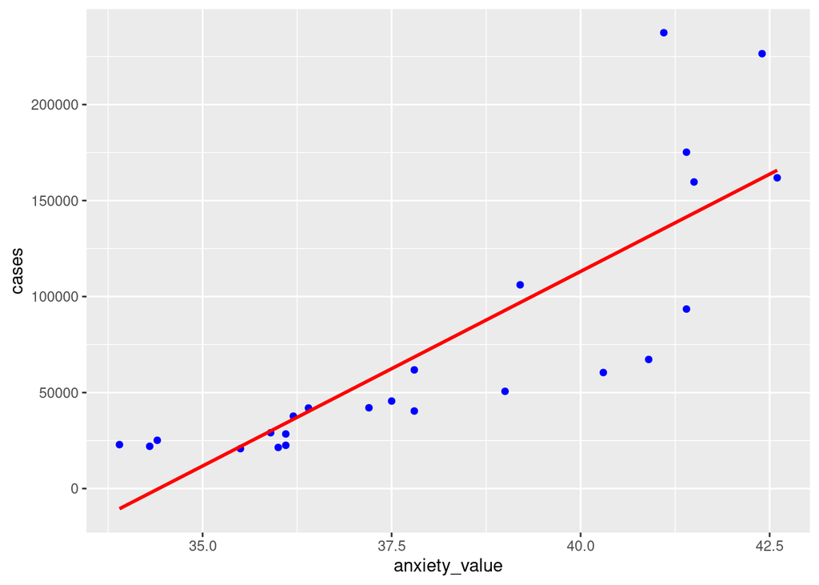

The raw case data in relation to anxiety value does not appear to be linear. The lm() line calculation does not fit all of the data evenly and has some tailing at the high end of cases and anxiety values. While there does appear to be a correlation, the relationship does not appear to be linear.

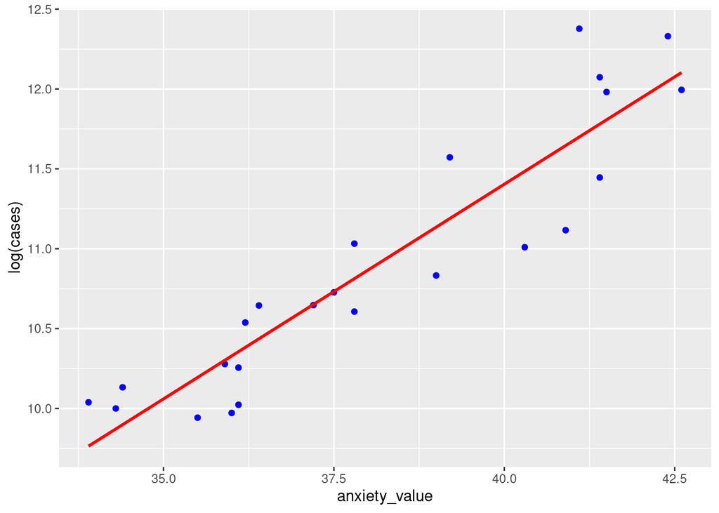

Upon an initial visualization to check for a linear relationship, we see that there is nothing to indicate otherwise. The data does not appear to be in any other form than linear. Log-transorming the data allows us to perform a linear regression as we cannot reject the assumption that the relationship is linear after tranforming the data.

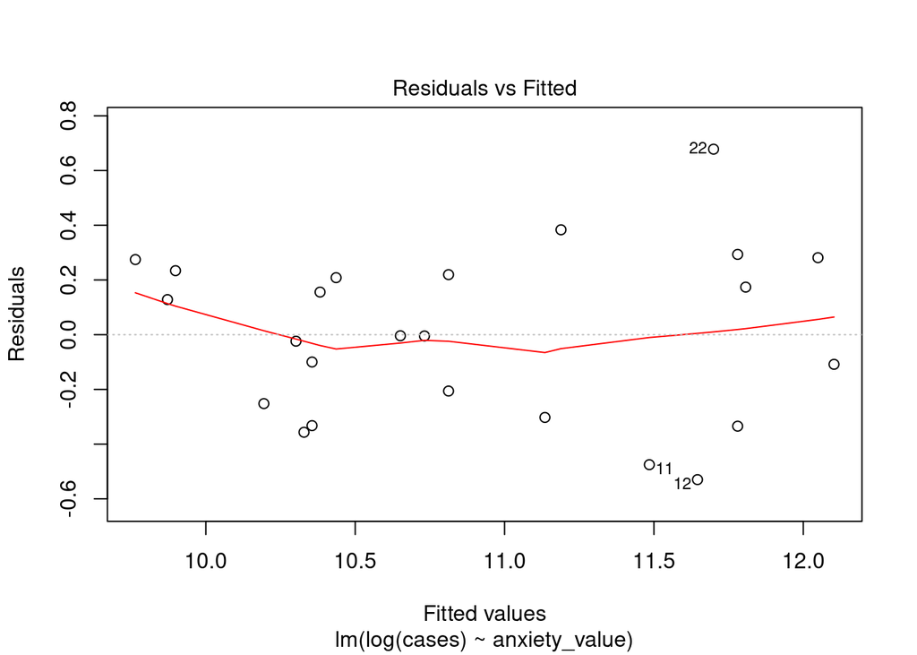

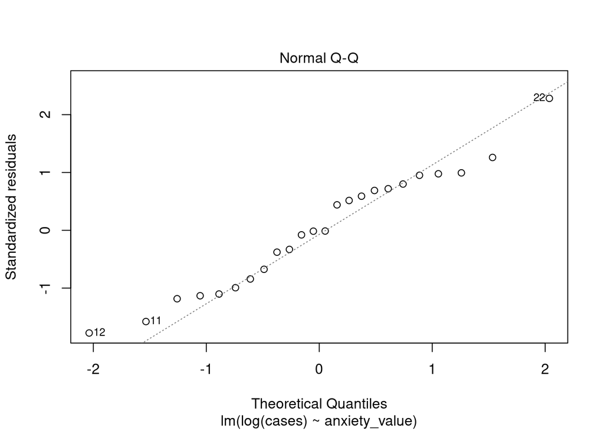

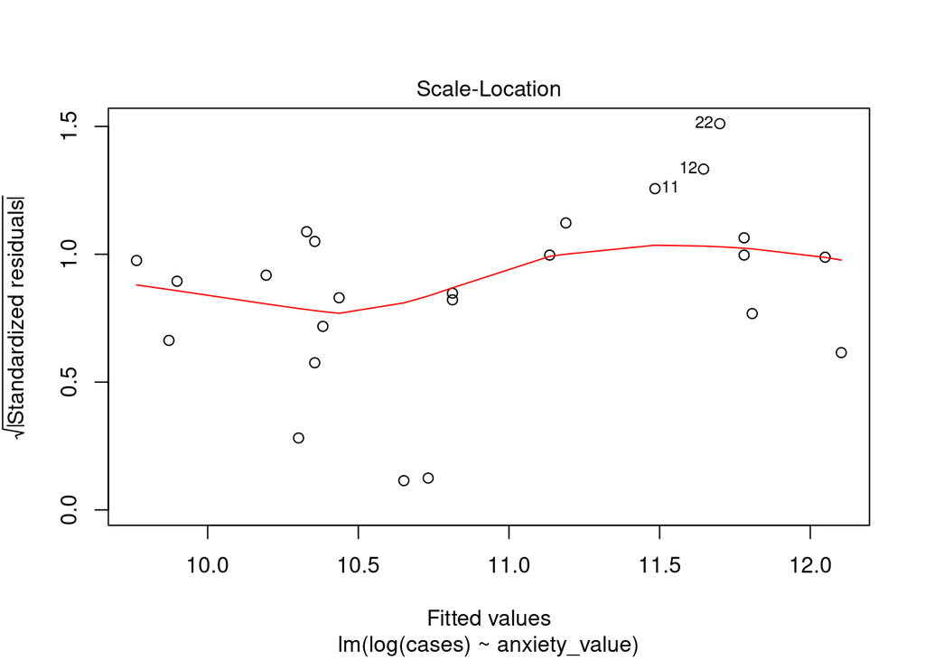

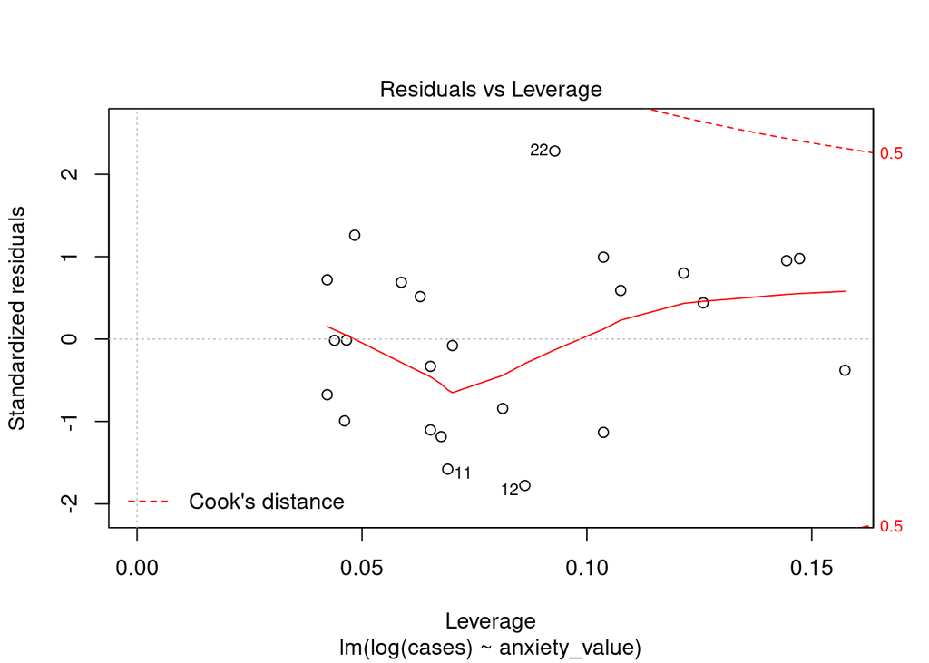

In the residual plot, we want to check that the fitted residual line is mostly horizontal. We want our residual plot to have randomly distributed error terms with no clear pattern that are relatively close to this fitted line. In the model that relates log-transformed case counts and anxiety rates in the survey, we see this line is not perfectly horizontal, but nothing concerning to throw out the entire model. Some of the data is not spread evenly and there may be a couple outliers.

In the Normal Q-Q plot, we want to see that most of the data points are on the theoretical dashed line incicating normality. Our data here has a majority of the points near this line and has some tailing on either end of the distribution but nothing major. This would indicate normal distribution.

The Scale-Location plot, similar to the residual plot, wants a fitted line as horizontal as possible. Here we see similar results with no major deviations from a horizontal fitted line and a similar spread which should be looked into further via Cook’s distance to determine outliers.

In the Residuals vs leverage plot with Cook’s distance, we see that there are no points that pass the Cook’s distance line. Since no points are outside the line our model assumptions hold.

### Insights and Suggestions for Future Analysis

All our assumptions appear to hold for the model that related log-transformed case counts and anxiety rates in the country. While some data points come close to the Cook’s distance line of 0.5 and our residual plot is not as great as it could be, there is not strong enough evidence in these plots to reject the model and it’s assumptions.

# Conclusion

Our analysis finds that there is a relationship between COVID-Cases in the United States and anxiety rates. The model itself has a very low p-value which indicates that the null hypothesis of no relationship is rejected rather conclusively. In addition a high Adjusted $R^2$ of 0.8475 suggests the two observations are highly correlated.

The analysis was conducted by aggregating the daily case data found in the WHO data set with the anxiety data used from the CDC. Using this, a linear model was created to analyze the relationship between case rates and anxiety rates. It was found that there is a relationship between these two variables with an extremely low p-value with the model assumptions appearing to hold.

One major factor to keep in mind is that depression has been studied extensively and many factors have been found to be related to depression. Some of these factors include staying indoors extensively, loss of employment, among other things. Many factors of life linked to increased depression can also be related to the rise in COVID-19 cases. For example, the increase in cases resulted in an increase in unemployment as businesses were forced to shut down due to the newest restrictions. Thus, the unemployment rate could be a cofounder that obfuscates the true cause in increase in anxiety rates. Other factors such as an increase in family or friends dying as a result of the pandemic could certainly have a significant impact on overall mental health. It is important to not conclude that COVID-19 cases *cause* increase anxiety rates but we simply showed there was a relationship in this analysis.

# References

Abbott, A. (2021). COVID’s mental-health toll: how scientists are tracking a surge in depression. Nature, 590(7845), 194–195. https://doi.org/10.1038/d41586-021-00175-z

Brodeur, A., Clark, A. E., Fleche, S., & Powdthavee, N. (2021). COVID-19, lockdowns and well-being: Evidence from Google Trends. Journal of Public Economics, 193, 104346. https://doi.org/10.1016/j.jpubeco.2020.104346

Bui, C. N., Peng, C., Mutchler, J. E., & Burr, J. A. (2020). Race and Ethnic Group Disparities in Emotional Distress Among Older Adults During the COVID-19 Pandemic. The Gerontologist, 61(2), 262–272. https://doi.org/10.1093/geront/gnaa217

Clemente-Suárez, V. J., Dalamitros, A. A., Beltran-Velasco, A. I., Mielgo-Ayuso, J., & Tornero-Aguilera, J. F. (2020). Social and Psychophysiological Consequences of the COVID-19 Pandemic: An Extensive Literature Review. Frontiers in Psychology, 11, 1–15. https://doi.org/10.3389/fpsyg.2020.580225

Delmastro, M., & Zamariola, G. (2020). Depressive symptoms in response to COVID-19 and lockdown: a cross-sectional study on the Italian population. Scientific Reports, 10(1), 1–10. https://doi.org/10.1038/s41598-020-79850-6

Fields JF, Hunter-Childs J, Tersine A, Sisson J, Parker E, Velkoff V, Logan C, and Shin H. Design and Operation of the 2020 Household Pulse Survey, 2020. U.S. Census Bureau. Forthcoming. Ganson, K. T., Tsai, A. C., Weiser, S. D., Benabou, S. E., & Nagata, J. M. (2021). Job Insecurity and Symptoms of Anxiety and Depression Among U.S. Young Adults During COVID-19. Journal of Adolescent Health, 68(1), 53–56. https://doi.org/10.1016/j.jadohealth.2020.10.008

Holmes, E. A., O’Connor, R. C., Perry, V. H., Tracey, I., Wessely, S., Arseneault, L., Ballard, C., Christensen, H., Cohen Silver, R., Everall, I., Ford, T., John, A., Kabir, T., King, K., Madan, I., Michie, S., Przybylski, A. K., Shafran, R., Sweeney, A., … Bullmore, E. (2020). Multidisciplinary research priorities for the COVID-19 pandemic: a call for action for mental health science. The Lancet Psychiatry, 7(6), 547–560. https://doi.org/10.1016/s2215-0366(20)30168-1

WHO COVID-19 Dashboard. Geneva: World Health Organization, 2020. Available online: https://covid19.who.int/

# Appendix

```r
# Setup this markdown file:
knitr::opts_chunk$set(
  fig.pos = 'H',
  warning = FALSE,
  message = FALSE,
  eval = TRUE,
  echo = FALSE,
  fig.align='center'
)
# Include all necessary libraries
library(tidyverse)
library(usmap)
library(reshape2)
library(lubridate)
library(rstatix)
library(gt)
# Import WHO COVID Data, CDC Depression and Anxiety Data, and Google Trends
covid <- read.csv(file = "WHO-COVID-19-global-data.csv", fileEncoding="UTF-8-BOM")
indicators <- read.csv(file = "CDC_Anxiety.csv", header=T)
GOOGLE <- read.csv(file = "Google_US_Depression_Anxiety.csv")

# Convert date column to POSIXct
GOOGLE$Week <- as.POSIXct(GOOGLE$Week)
GOOGLE <- subset(GOOGLE, Week >= as.POSIXct("2020-01-01"))

# subset covid data to include only US data
covid_US = subset(covid, Country == "United States of America") %>% select(Date_reported,New_cases,Cumulative_cases,New_deaths,Cumulative_deaths)
covid_US$Date_reported <- as.POSIXct(covid_US$Date_reported, format = "%Y-%m-%d")

# subset CDC anxiety data to include only the measures for anxiety or depressive disorder (combined) and the national measure
indicators_US = subset(indicators, Indicator == "Symptoms of Anxiety Disorder or Depressive Disorder" &
                         Group == "National Estimate" ) %>%     select(Time.Period,Time.Period.Label,Time.Period.Start.Date,Time.Period.End.Date,Value,Low.CI,High.CI,Quartile.Range)

# remove na data from the indicators leaving 24 values for 24 distinct time periods
indicators_US.narm <- indicators_US %>% filter(!is.na(Value))

# Convert start/end date to standard format.
indicators_US.narm$Time.Period.Start.Date <- as.POSIXct(indicators_US.narm$Time.Period.Start.Date, format = "%m/%d/%Y")
indicators_US.narm$Time.Period.End.Date <- as.POSIXct(indicators_US.narm$Time.Period.End.Date, format = "%m/%d/%Y")
# Present Depression or Anxiety Information by Race
indicators.race <- subset(indicators, Indicator == "Symptoms of Anxiety Disorder or Depressive Disorder" &
                         Group == "By Race/Hispanic ethnicity", c(Subgroup, Value)) %>% filter(!is.na(Value))
indicators.race$Subgroup <- as.character(indicators.race$Subgroup)
indicators.race.means <- aggregate(indicators.race, list(indicators.race$Subgroup), mean)
ggplot(indicators.race.means, aes(x=Value, y=Group.1, )) +
  geom_bar(aes(fill=Group.1), stat = "identity", position = "dodge") +
  theme(legend.position = "none") +
  labs(title = "Depression or Anxiety Symptoms by Race",
       subtitle = "Average 2020 Household Pulse Survey",
       x = "Average % of Survey Responses Indicating Anxiety or Depression",
       y = "")

# Present Depression or Anxiety Information by Sex
indicators.sex <- subset(indicators, Indicator == "Symptoms of Anxiety Disorder or Depressive Disorder" &
                         Group == "By Gender",c(Subgroup, Value))  %>% filter(!is.na(Value))
indicators.sex.means <- aggregate(indicators.sex, list(indicators.sex$Subgroup), mean)
# ggplot(indicators.sex.means, aes(x=Value, y=Group.1)) +
#  geom_bar(aes(fill=Group.1), stat = "identity", position = "dodge") +
#  theme(legend.position = "none") +
#  labs(title = "Depression or Anxiety Symptoms by Sex",
#       subtitle = "Average 2020 Household Pulse Survey",
#       x = "Average % of Survey Responses Indicating Anxiety or Depression",
#       y = "")

# Present Depression or Anxiety Information by State
indicators.state <- subset(indicators, Indicator == "Symptoms of Anxiety Disorder or Depressive Disorder" &
                         Group == "By State", c(Subgroup,Value))  %>% filter(!is.na(Value))
indicators.state.means <- aggregate(indicators.state, list(indicators.state$Subgroup), mean) %>% select(Group.1,Value)
indicators.state.means$Group.1 <- usmap::fips(indicators.state.means$Group.1)
names(indicators.state.means) <- c('fips','Value')
usmap::plot_usmap(data=indicators.state.means, values="Value") +
  theme(legend.position = 'right') +
  labs(title = "Depression or Anxiety Symptoms by State", subtitle = "Average 2020 Household Pulse Survey") +
  scale_fill_continuous(low = "yellow", high = "blue", name = "Anxiety or Depression Percentage")
# Fill in dates of indicators and GOOGLE
HPS <- list()
for (i in 1:(dim(indicators_US.narm)[1]-1)) {
  fill.dates <- seq(indicators_US.narm[i,'Time.Period.Start.Date'], indicators_US.narm[i+1,'Time.Period.Start.Date'] - 1*60*60*24, by="days")
  fill.values <- c(rep(1,length(fill.dates)))*indicators_US.narm[i,'Value']
  fill.dates.df <- data.frame(fill.dates,fill.values)
  HPS[[i]] <- fill.dates.df
}
HPS.full <- bind_rows(HPS)

Trends.Anxiety <- list()
Trends.Depression <- list()
for (i in 1:(dim(GOOGLE)[1]-1)) {
  fill.dates <- seq(GOOGLE[i,'Week'], GOOGLE[i+1,'Week'] - 1*60*60*24, by="days")
  fill.anxiety.values <- c(rep(1,length(fill.dates)))*GOOGLE[i,'Anxiety...United.States.']
  fill.depression.values <- c(rep(1,length(fill.dates)))*GOOGLE[i,'Depression...United.States.']
  fill.dates.df <- data.frame(fill.dates,fill.anxiety.values)
  Trends.Anxiety[[i]] <- fill.dates.df
  fill.dates.df <- data.frame(fill.dates,fill.depression.values)
  Trends.Depression[[i]] <- fill.dates.df
}
Trends.Anxiety.Full <- bind_rows(Trends.Anxiety)
Trends.Depression.Full <- bind_rows(Trends.Depression)

# Combine into one dataframe
all.covid <- covid_US %>% subset(Date_reported >= as.POSIXct("2020-04-23") & Date_reported < as.POSIXct("2021-01-01"),c(Date_reported,New_cases,New_deaths))
all.Anxiety <- Trends.Anxiety.Full %>% subset(fill.dates >= as.POSIXct("2020-04-23") & fill.dates < as.POSIXct("2021-01-01"))
all.Depression <- Trends.Depression.Full %>% subset(fill.dates >= as.POSIXct("2020-04-23") & fill.dates < as.POSIXct("2021-01-01"))
all.HPS <- HPS.full %>% subset(fill.dates >= as.POSIXct("2020-04-23") & fill.dates < as.POSIXct("2021-01-01"))
all.df <- data.frame(all.covid,all.Anxiety$fill.anxiety.values,all.Depression$fill.depression.values,all.HPS$fill.values)
names(all.df) <- c("Date","New Cases","New Deaths","Anxiety Google Trends","Depression Google Trends","Household Pulse Survey")
# Show daily deaths, cases, anxiety|depression, and google trends overtime
all.df.m <- melt(all.df, "Date")
# New_cases,New_deaths,all.Anxiety.fill.anxiety.values,all.Depression.fill.depression.values,all.HPS.fill.values
options(repr.plot.width = 8, repr.plot.height = 0.75)
ggplot(all.df.m, aes(Date,value,colour = variable)) +
  geom_point() +
  geom_point() +
  geom_point() +
  geom_point() +
  geom_point() +
  facet_wrap(~ variable, ncol=1,scales = "free_y") +
  labs(title = "Depression or Anxiety Symptoms",
       subtitle = "Average 2020 Household Pulse Survey",
       y = "Value of respective datasets (in order top to bottom): [Cases] [Deaths] [% trend], [% trend], [% with symptoms]") +
  theme(text = element_text(size = 12), element_line(size = 0.2))
covid.US.Months <- data.frame(covid_US) %>% subset(Date_reported >= as.POSIXct("2020-01-01") & Date_reported < as.POSIXct("2021-01-01"),c(Date_reported,New_cases,New_deaths))
covid.US.Months$Date_reported <- format(covid.US.Months$Date_reported, "01-%m-%Y")
covid.US.Months.stats.cases <- covid.US.Months %>%
                                select(Date_reported,New_cases) %>%
                                group_by(Date_reported) %>%
                                get_summary_stats(type='common')
covid.US.Months.stats.deaths <- covid.US.Months %>%
                                  select(Date_reported,New_deaths) %>%
                                  group_by(Date_reported) %>%
                                  get_summary_stats(type='common')
# covid.US.Months.stats.cases %>%
#   select('Date_reported','min','max','median','mean','sd') %>%
#   gt() %>%
#   tab_header(
#     title = "2020 COVID-19 Cases",
#     subtitle = "Values per day of each month"
#   ) %>%
#   fmt_date(
#     columns = vars(Date_reported),
#     date_style = 11
#   ) %>%
#   fmt_number(
#     columns = vars(min,max,median,mean,sd),
#     decimals = 0
#   )
#
# covid.US.Months.stats.deaths %>%
#   select('Date_reported','min','max','median','mean','sd') %>%
#   gt() %>%
#   tab_header(
#     title = "2020 COVID-19 Deaths",
#     subtitle = "Values per day of each month"
#   ) %>%
#   fmt_date(
#     columns = vars(Date_reported),
#     date_style = 11
#   ) %>%
#   fmt_number(
#     columns = vars(min,max,median,mean,sd),
#     decimals = 0
#   )
#plot looking at the cumulative deaths over the dates reported
qplot(Date_reported, Cumulative_deaths, data = covid_US)
```

```r
#plot looking at the cases of covid over the dates reported
qplot(Date_reported, New_cases, data = covid_US)

#plot looking at the CDC anxiety data over the time reported
qplot(Time.Period, Value, data = indicators_US.narm)
dates1 = covid_US[112:124,]
dates2 = covid_US[126:131,]
dates3 = covid_US[133:138,]
dates4 = covid_US[140:145,]
dates5 = covid_US[147:152,]
dates6 = covid_US[154:159,]
dates7 = covid_US[161:166,]
dates8 = covid_US[168:173,]
dates9 = covid_US[175:180,]
dates10 = covid_US[182:187,]
dates11 = covid_US[189:194,]
dates12 = covid_US[196:201,]
dates13 = covid_US[230:242,]
dates14 = covid_US[244:256,]
dates15 = covid_US[258:270,]
dates16 = covid_US[272:284,]
dates17 = covid_US[286:298,]
dates18 = covid_US[300:312,]
dates19 = covid_US[314:326,]
dates20 = covid_US[328:340,]
dates21 = covid_US[342:354,]
dates22 = covid_US[370:382,]
dates23 = covid_US[384:396,]
dates24 = covid_US[398:410,]

dates1_cases = mean(dates1$New_cases)
dates1_deaths = mean(dates1$New_deaths)

dates2_cases = mean(dates2$New_cases)
dates2_deaths = mean(dates2$New_deaths)

dates3_cases = mean(dates3$New_cases)
dates3_deaths = mean(dates3$New_deaths)

dates4_cases = mean(dates4$New_cases)
dates4_deaths = mean(dates4$New_deaths)

dates5_cases = mean(dates5$New_cases)
dates5_deaths = mean(dates5$New_deaths)

dates6_cases = mean(dates6$New_cases)
dates6_deaths = mean(dates6$New_deaths)

dates7_cases = mean(dates7$New_cases)
dates7_deaths = mean(dates7$New_deaths)

dates8_cases = mean(dates8$New_cases)
dates8_deaths = mean(dates8$New_deaths)

dates9_cases = mean(dates9$New_cases)
dates9_deaths = mean(dates9$New_deaths)

dates10_cases = mean(dates10$New_cases)
dates10_deaths = mean(dates10$New_deaths)

dates11_cases = mean(dates11$New_cases)
dates11_deaths = mean(dates11$New_deaths)

dates12_cases = mean(dates12$New_cases)
dates12_deaths = mean(dates12$New_deaths)

dates13_cases = mean(dates13$New_cases)
dates13_deaths = mean(dates13$New_deaths)

dates14_cases = mean(dates14$New_cases)
dates14_deaths = mean(dates14$New_deaths)

dates15_cases = mean(dates15$New_cases)
dates15_deaths = mean(dates15$New_deaths)

dates16_cases = mean(dates16$New_cases)
dates16_deaths = mean(dates16$New_deaths)

dates17_cases = mean(dates17$New_cases)
dates17_deaths = mean(dates17$New_deaths)

dates18_cases = mean(dates18$New_cases)
dates18_deaths = mean(dates18$New_deaths)

dates19_cases = mean(dates19$New_cases)
dates19_deaths = mean(dates19$New_deaths)

dates20_cases = mean(dates20$New_cases)
dates20_deaths = mean(dates20$New_deaths)

dates21_cases = mean(dates21$New_cases)
dates21_deaths = mean(dates21$New_deaths)

dates22_cases = mean(dates22$New_cases)
dates22_deaths = mean(dates22$New_deaths)

dates23_cases = mean(dates23$New_cases)
dates23_deaths = mean(dates23$New_deaths)

dates24_cases = mean(dates24$New_cases)
dates24_deaths = mean(dates24$New_deaths)

dates = c("dates1", "dates2", "dates3", "dates4", "dates5", "dates 6", "dates7", "dates8", "dates9", "dates10", "dates11", "dates12", "dates13", "dates14", "dates15", "dates16", "dates17", "dates18", "dates19", "dates20", "dates21", "dates22", "dates23", "dates24")

cases = c(dates1_cases, dates2_cases, dates3_cases, dates4_cases, dates5_cases, dates6_cases, dates7_cases, dates8_cases, dates9_cases, dates10_cases, dates11_cases, dates12_cases, dates13_cases, dates14_cases, dates15_cases, dates16_cases, dates17_cases, dates18_cases, dates19_cases, dates20_cases, dates21_cases, dates22_cases, dates23_cases, dates24_cases)

deaths = c(dates1_deaths, dates2_deaths, dates3_deaths, dates4_deaths, dates5_deaths, dates6_deaths, dates7_deaths, dates8_deaths, dates9_deaths, dates10_deaths, dates11_deaths, dates12_deaths, dates13_deaths, dates14_deaths, dates15_deaths, dates16_deaths, dates17_deaths, dates18_deaths, dates19_deaths, dates20_deaths, dates21_deaths, dates22_deaths, dates23_deaths, dates24_deaths)

anxiety_value = indicators_US.narm$Value

#The compiled data has the date, the average number of cases for that date period, the average number of deaths for that date #period, and the reported CDC anxiety value for that data period.
compiled_data = data.frame(dates, cases, deaths, anxiety_value)
compiled_data
#Plot showing new cases vs anxiety value
plot(x=cases, y=anxiety_value, main="cases ~ anxiety_value")

#Plot showing new deaths vs anxiety value
plot(x=deaths, y=anxiety_value, main="deaths ~ anxiety_value")
linearMod_cases <- lm(log(cases) ~ anxiety_value, data=compiled_data)
summary(linearMod_cases)
#Basic linear model relating new deaths vs anxiety value, the reported summary shows that the slope (depression_value) is not #significant and positive for this relationship.
linearMod_deaths <- lm(log(deaths) ~ anxiety_value, data=compiled_data)
summary(linearMod_deaths)
  ggplot(data = compiled_data, aes(x = anxiety_value, y=cases)) +
    geom_point(color = 'blue') +
    geom_smooth(method = "lm", se = FALSE, color = 'red')
  ggplot(data = compiled_data, aes(x = anxiety_value, y=log(cases))) +
    geom_point(color = 'blue') +
    geom_smooth(method = "lm", se = FALSE, color = 'red')
  plot(linearMod_cases)
```